# PS1

**Lorenzo Paletto** Dottorando in **Modeling and Data Science**

This report shows and discusses the results of Problem Set 1. The code is available at the following Github link https://github.com/CasellaJr/MultivariateStatAnalysis and has been written together with the PhD student Bruno Casella.

## Exercise 1

We upload the data and preprocess it according to the problem instructions. We decide to change the names of the columns to make them shorter.

```r
dim(DF)
```

```
## [1] 41  6
```

```r
# old names = "Neg.Temp" "Manuf"  "Pop"   "Wind"  "Precip"  "Days"
head(DF)
```

```
##                  x1  x2  x3  x4    x5  x6
## Phoenix       -70.3 213 582 6.0  7.05  36
## Little Rock   -61.0  91 132 8.2 48.52 100
## San Francisco -56.7 453 716 8.7 20.66  67
## Denver        -51.9 454 515 9.0 12.95  86
## Hartford      -49.1 412 158 9.0 43.37 127
## Wilmington    -54.0  80  80 9.0 40.25 114
```

### 1.1

We compute the mean vector and the correlation matrix.

```r
x_bar <- colMeans(DF)
x_bar
```

```
##         x1         x2         x3         x4         x5         x6
## -55.763415 463.097561 608.609756   9.443902  36.769024 113.902439
```

```r
Cors <- cor(DF)
Cors
```

```
##             x1          x2          x3          x4          x5         x6
## x1  1.00000000  0.19004216  0.06267813  0.34973963 -0.38625342 0.43024212
## x2  0.19004216  1.00000000  0.95526935  0.23794683 -0.03241688 0.13182930
## x3  0.06267813  0.95526935  1.00000000  0.21264375 -0.02611873 0.04208319
## x4  0.34973963  0.23794683  0.21264375  1.00000000 -0.01299438 0.16410559
## x5 -0.38625342 -0.03241688 -0.02611873 -0.01299438  1.00000000 0.49609671
## x6  0.43024212  0.13182930  0.04208319  0.16410559  0.49609671 1.00000000
```

We now comment on the correlations among variables.

$X_1$ is lightly positive correlated with both the human ecology variables, which means that the mean temperature of the cities does not effect their populations and that big enterprises are more present in colder cities but only slightly. It is positive correlated with the other climate variables but not with the inches of fallen rain, this might mean that in colder cities there are more rainy days but they do not bring much water, while in hotter cities the few rainy days bring a lot of water.

$X_2$ has a very high correlation of $.96$ with $X_3$ stating that cities’ population grows together with the number of big enterprises. Both the variables have no strong correlation with the other ones except fot a light positive correlation with the wind speed, possibly because wind moves the smog so enterprises tend to grow in big cities because part of their smog production is ‘masked’ by the wind.

The last climate variables, $X_4, \dots, X_6$ are lightly correlated among them, except for the ones related to precipitations that have a correlation of almost $0.5$. This correlation is not high as one might expect and supports the speculation we made about hotter cities and intensity of the precipitations.

### 1.2

We now investigate univariate outliers.

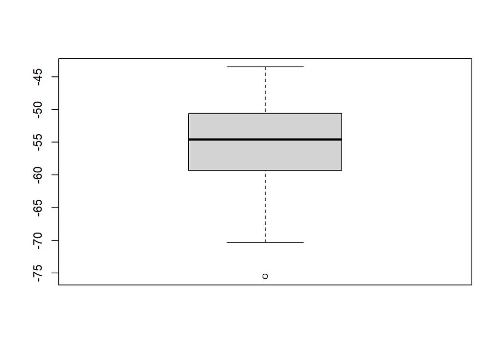

```r
# Negative temperature
boxplot(x1)
```

```r
which(x1 < -71)
```

```
## [1] 9
```

There is only one outlier which is Miami, one of the cityes most south located in the US and one of the hottest.

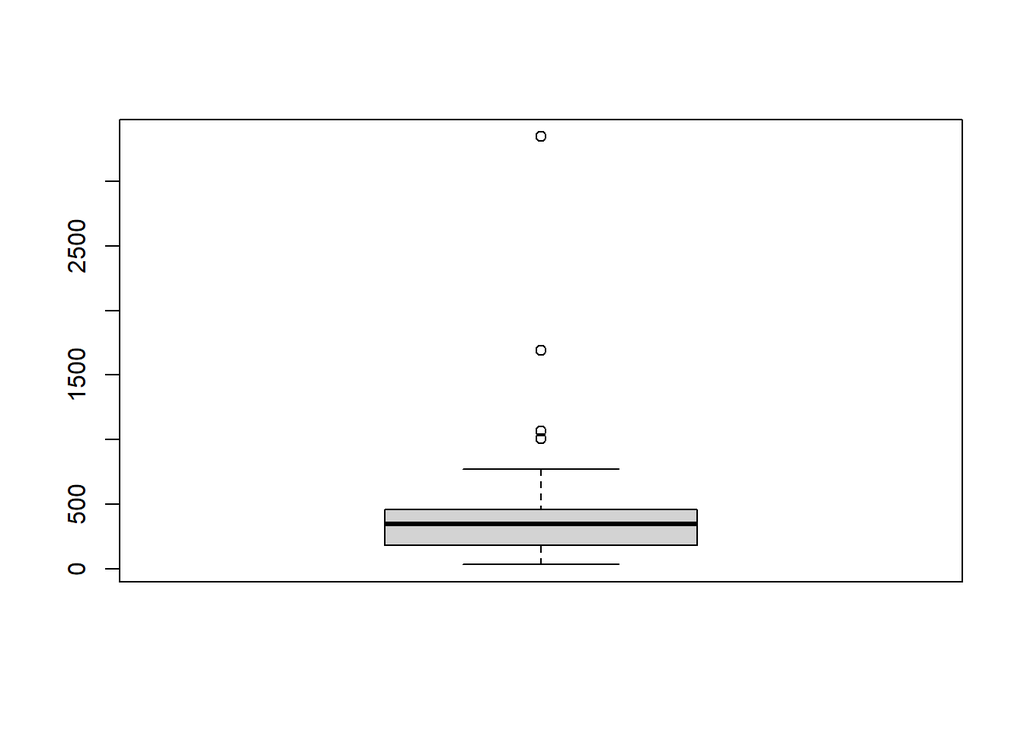

```r
boxplot(x2)
```

```r
which(x2 > 1500)
```

```
## [1] 11 29
```

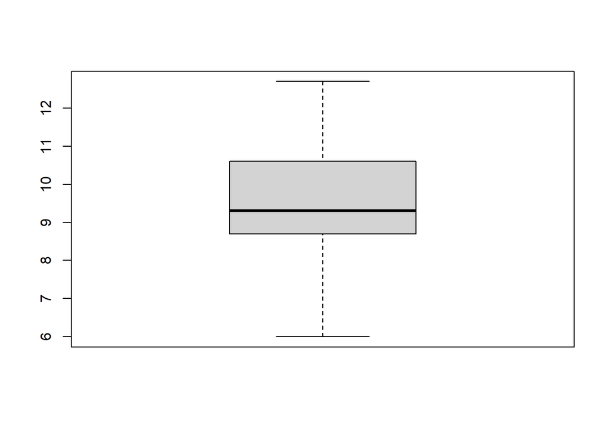

```r
boxplot(x4)
```

This boxplot does not show the presence of outliers.

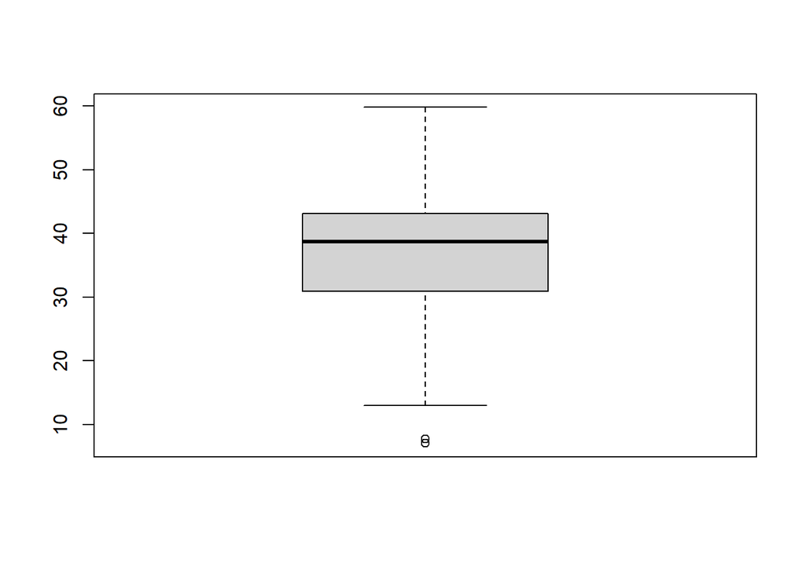

```r
boxplot(x5)
```

```r
which(x5 < 10)
```

```
## [1]  1 23
```

We can get the same results in terms of the Mahalanobis distances by using this snippet of code and then plotting boxplots of the single columns of the modified dataset.

```r
DF_centr = sweep(DF,2,x_bar)
varianze = diag(cov(DF))  # = diag(cov(DF_centr))
for (i in 1:6){
    DF_centr[,i] <- DF_centr[,i]/varianze[i]
}
# boxplot(DF_centr$x1) ...
```

### 1.3

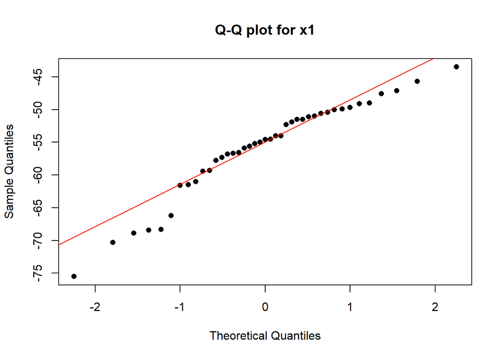

```r
qqnorm(x1,pch=16,main="Q-Q plot for x1")
qqline(x1,col="red")
```

```r
skewness(x1)
```

```
## [1] -0.8540294
```

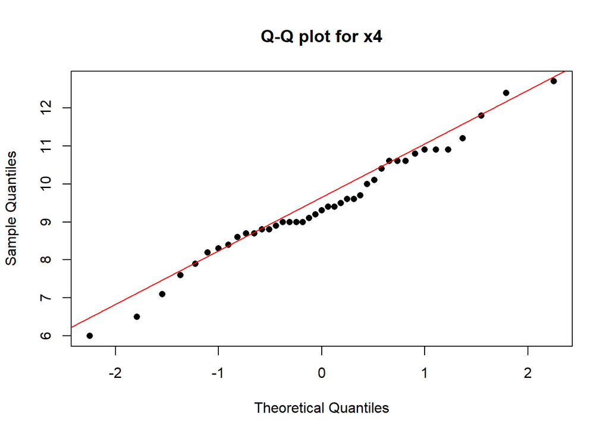

```r
qqnorm(x4,pch=16,main="Q-Q plot for x4")
qqline(x4,col="red")
```

```r
skewness(x4)
```

```
## [1] 0.002776073
```

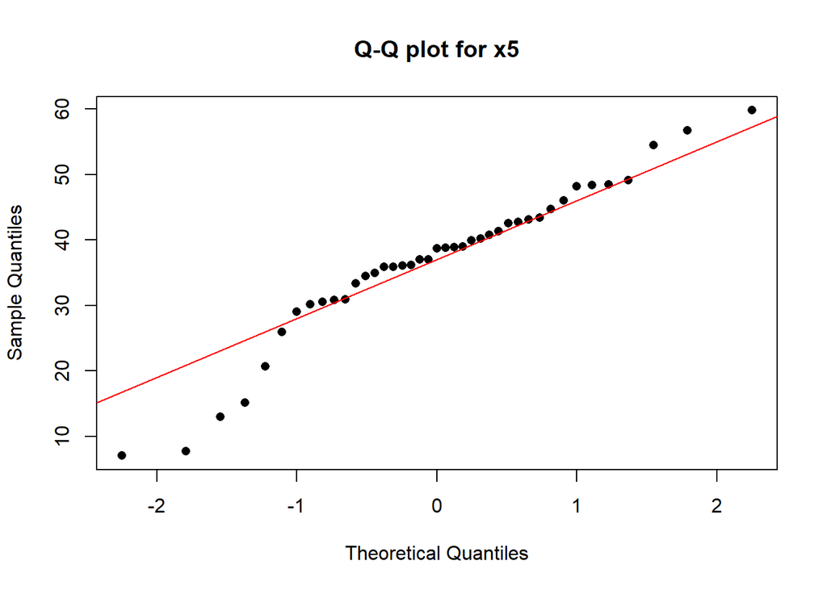

```r
qqnorm(x5,pch=16,main="Q-Q plot for x5")
qqline(x5,col="red")
```

```r
skewness(x4)
```

```
## [1] 0.002776073
```

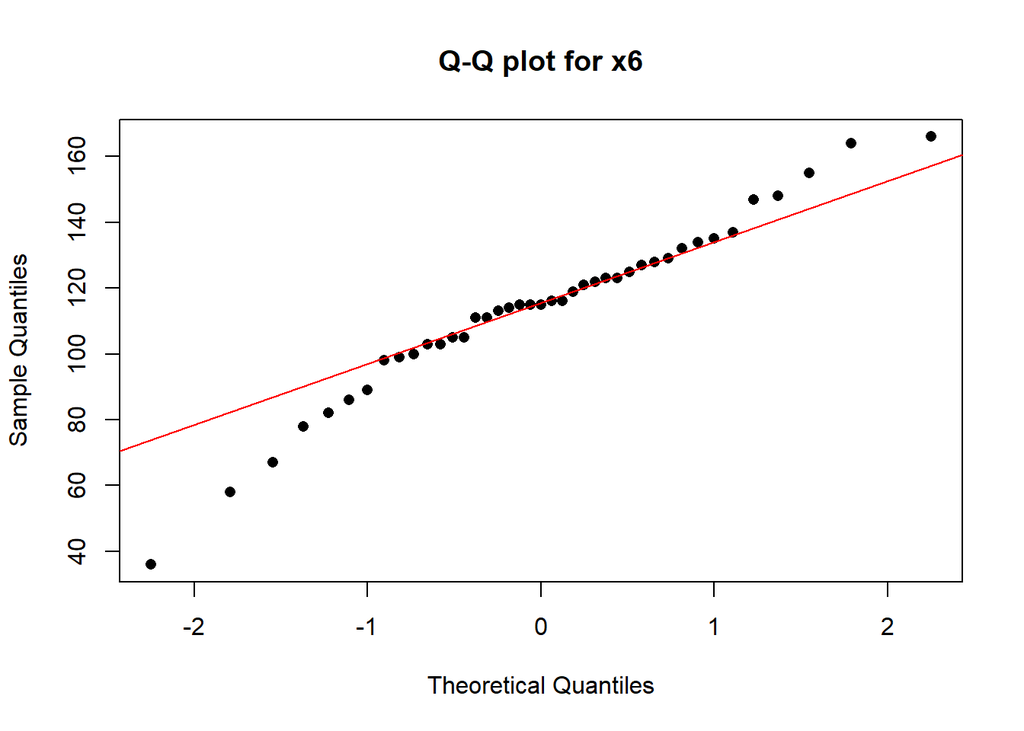

```r
qqnorm(x6,pch=16,main="Q-Q plot for x6")
qqline(x6,col="red")
```

```r
skewness(x6)
```

```
## [1] -0.5708491
```

The distributions of variables $X_1, X_4, X_5$ and $X_6$ look normal except for some observations in their tails, especially $X_5$ and $X_6$.

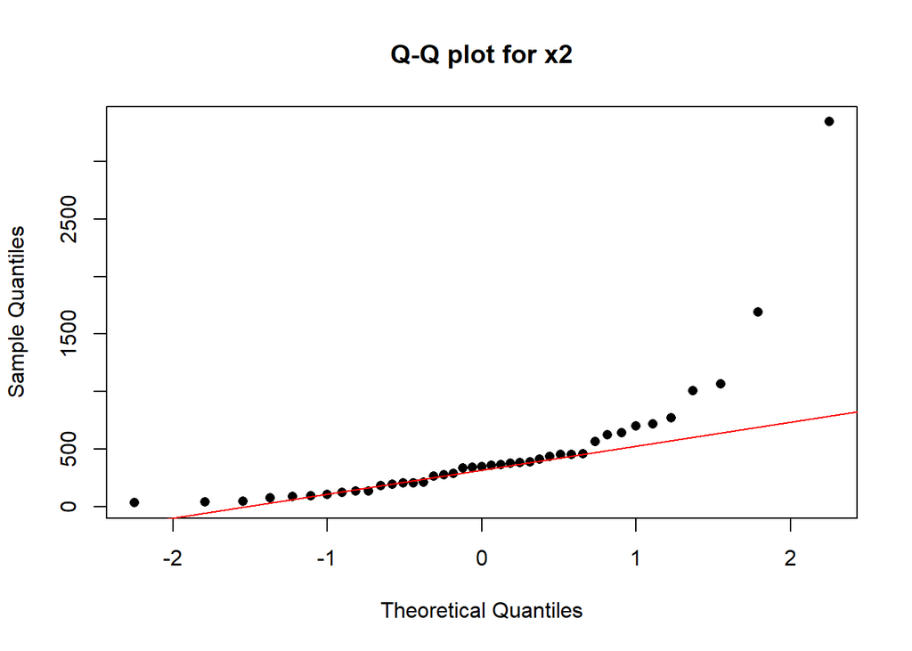

```r
qqnorm(x2,pch=16,main="Q-Q plot for x2")
qqline(x2,col="red")
```

```r
skewness(x2)
```

```
## [1] 3.616089
```

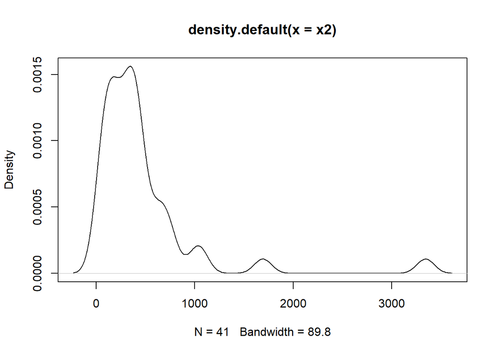

```r
plot(density(x2))
```

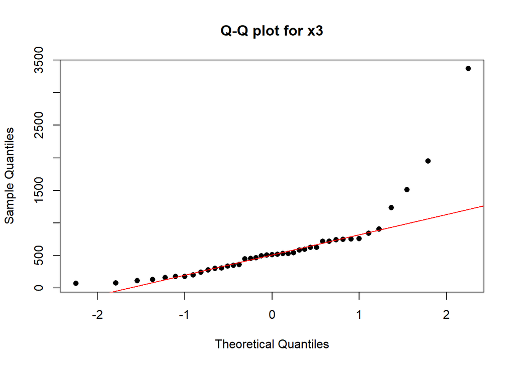

```r
qqnorm(x3,pch=16,main="Q-Q plot for x3")
qqline(x3,col="red")
```

```r
skewness(x3)
```

```
## [1] 3.052242
```

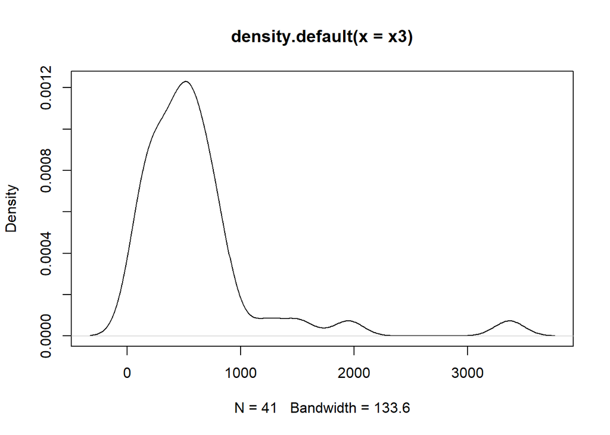

```r
plot(density(x3))
```

### 1.4

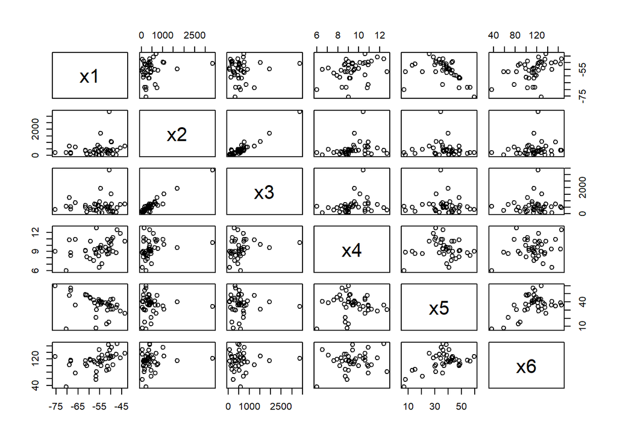

```r
pairs(DF)
```

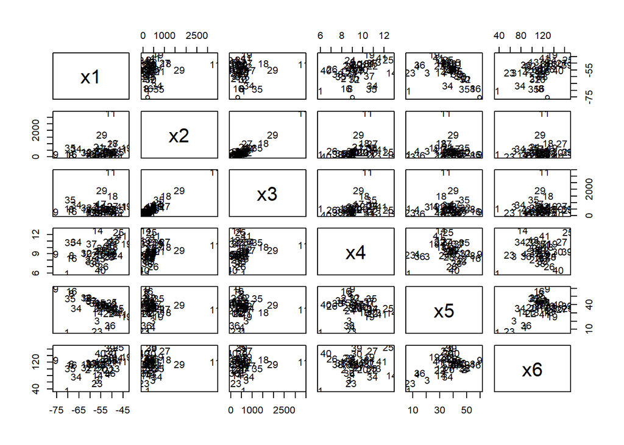

```r
pairs(DF, panel = function(x, y) text(x, y, labels = the.labels))
```

The scatterplots shows the presence of bivariate outliers, in particular from the second one we see that the most frequent outliers are observations 11 and 29, Chicago and Philadelphia, the univariate outliers for variables $X_2$ and $X_3$.

### 1.5 and 1.6

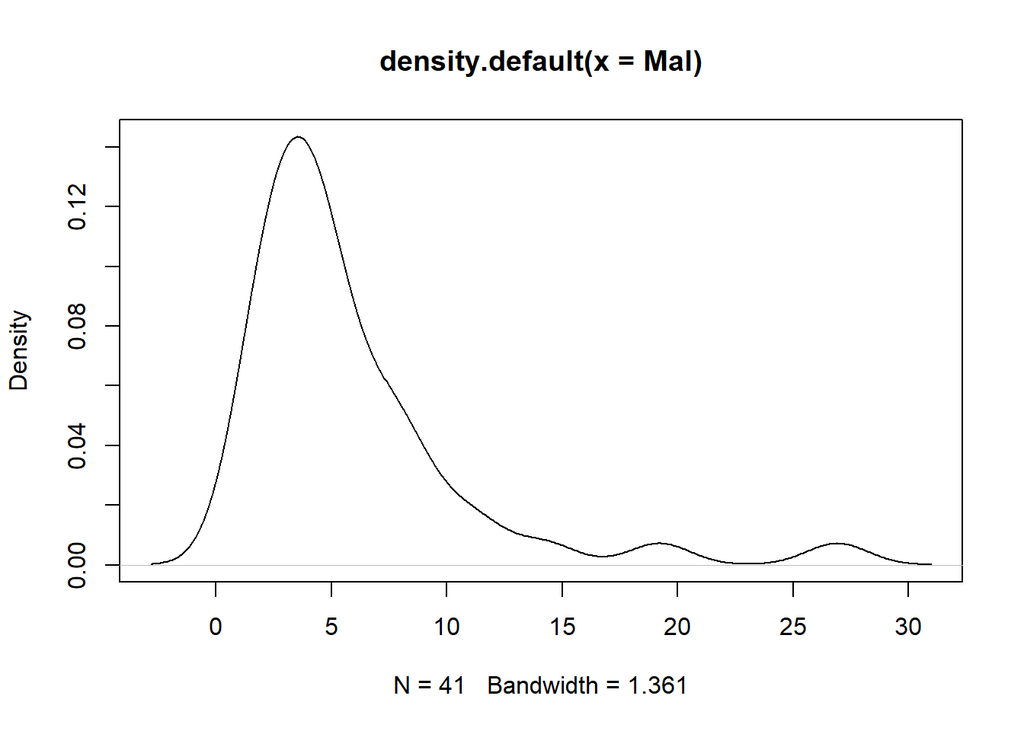

```r
Mal = mahalanobis(DF,center=x_bar,cov=var(DF))
plot(density(Mal))
```

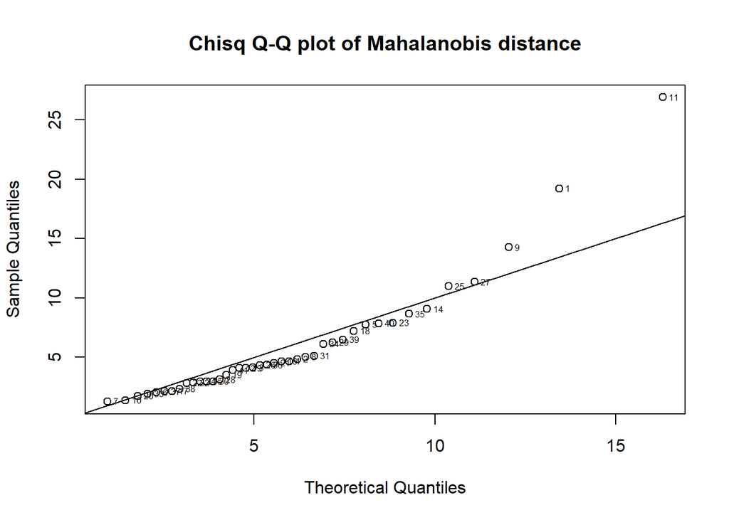

```r
plot(qchisq(ppoints(Mal),df=p),sort(Mal),main="Chisq Q-Q plot of Mahalanobis distance",
     xlab="Theoretical Quantiles",ylab="Sample Quantiles")
abline(0,1)
text(qchisq(ppoints(Mal),df=p),sort(Mal),label=order(Mal),
     pos=4,cex=0.5,offset=0.3)
```

The two outliers are again observations 9 and 11 together with observation 1, Phoenix, which was found as outlier for variable $X_5$.

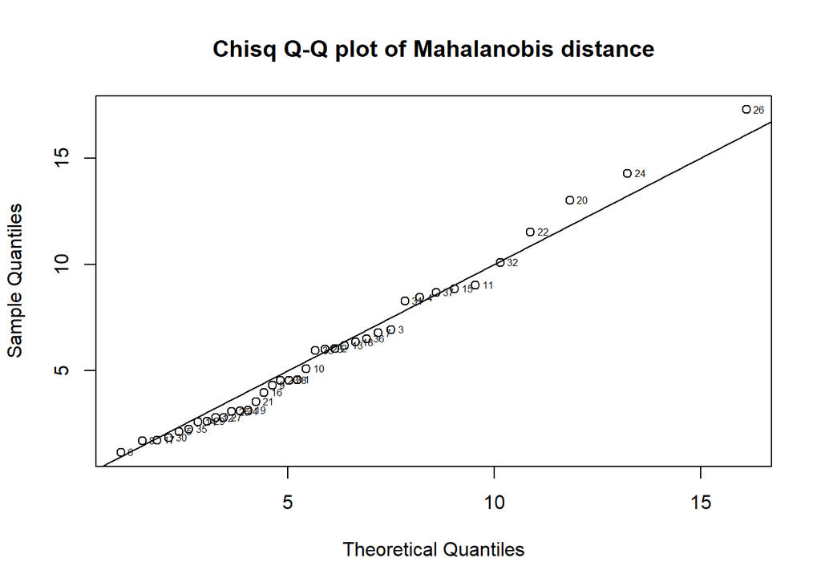

```r
DF2 <- DF[-c(1,9,11),]
no_out <- mahalanobis(DF2,center=colMeans(DF2),cov=var(DF2))
plot(qchisq(ppoints(no_out),df=p),sort(no_out),main="Chisq Q-Q plot of Mahalanobis distance",
     xlab="Theoretical Quantiles",ylab="Sample Quantiles")
abline(0,1)
text(qchisq(ppoints(no_out),df=p),sort(no_out),label=order(no_out),
     pos=4,cex=0.5,offset=0.3)
```

Once we remove the three outliers wee see that the multivariate distribution fits very well in the q-q plot testing for its normality. We can so state that the multivariate distribution of the dataset is normal but just without the outliers.

# Esercizio 2

### 2.1 and 2.2

On the PDF file. Here we show that simulating the data we get similar results to the theorical ones.

We define the two covariance matrices corresponding to $\rho = 0.1$ and $\rho = -0.1$.

```r
A
```

```
##      [,1] [,2] [,3]
## [1,]  1.0  0.1  0.0
## [2,]  0.1  1.0  0.1
## [3,]  0.0  0.1  1.0
```

```r
B
```

```
##      [,1] [,2] [,3]
## [1,]  1.0 -0.1  0.0
## [2,] -0.1  1.0 -0.1
## [3,]  0.0 -0.1  1.0
```

We then compute the eigenvalues and the eigenvectors of the matrices.

```r
eigA
```

```
## eigen() decomposition
## $values
## [1] 1.1414214 1.0000000 0.8585786
##
## $vectors
##           [,1]          [,2]       [,3]
## [1,] 0.5000000  7.071068e-01 -0.5000000
## [2,] 0.7071068  5.887847e-16  0.7071068
## [3,] 0.5000000 -7.071068e-01 -0.5000000
```

```r
eigB
```

```
## eigen() decomposition
## $values
## [1] 1.1414214 1.0000000 0.8585786
##
## $vectors
##            [,1]          [,2]      [,3]
## [1,] -0.5000000  7.071068e-01 0.5000000
## [2,]  0.7071068 -5.887847e-16 0.7071068
## [3,] -0.5000000 -7.071068e-01 0.5000000
```

The eigenvalues are $1 \pm \sqrt{2} \rho$ and $1$ and coincide with the ones found in the PDF, the same goes for the eigenvectors except for the sign of one of them but this depends on the software choices.

To compute the PC we simulate $10000$ realizations of the data given by the two covariance matrices and perform PCA.

```r
XA<- mvrnorm(n=10000, mu=c(1,-1,2), Sigma=A)
XB<- mvrnorm(n=10000, mu=c(1,-1,2), Sigma=B)
pca.normA<- prcomp(XA)
pca.normB<- prcomp(XB)
pca.normA$sdev^2
```

```
## [1] 1.1384862 0.9866748 0.8481390
```

```r
pca.normB$sdev^2
```

```
## [1] 1.1442761 1.0036015 0.8423694
```

```r
pca.normA$rotation
```

```
##            PC1         PC2        PC3
## [1,] 0.3899415 -0.76634540 -0.5105491
## [2,] 0.7388209 -0.07055821  0.6701979
## [3,] 0.5496265  0.63854230 -0.5386784
```

```r
pca.normB$rotation
```

```
##             PC1         PC2        PC3
## [1,]  0.4922988 -0.68427677 -0.5379658
## [2,] -0.7026841  0.05231379 -0.7095761
## [3,]  0.5136895  0.72734350 -0.4550764
```

The results are coherent with the theorical ones except for some numerical differences due to the fact that now we are simulating.

### 2.3

On the PDF file.

### 2.4

We define the parameters of the distribution given by $\rho = -2/3$.

```r
rho <- -2/3
muz <- c(2,-3)
Sigz <- matrix(c(2-2*rho, 2*rho-1, 2*rho-1, 2-2*rho), ncol=2, ,byrow = T)
Sigz
```

```
##           [,1]      [,2]
## [1,]  3.333333 -2.333333
## [2,] -2.333333  3.333333
```

We then plot the requested ellipse.

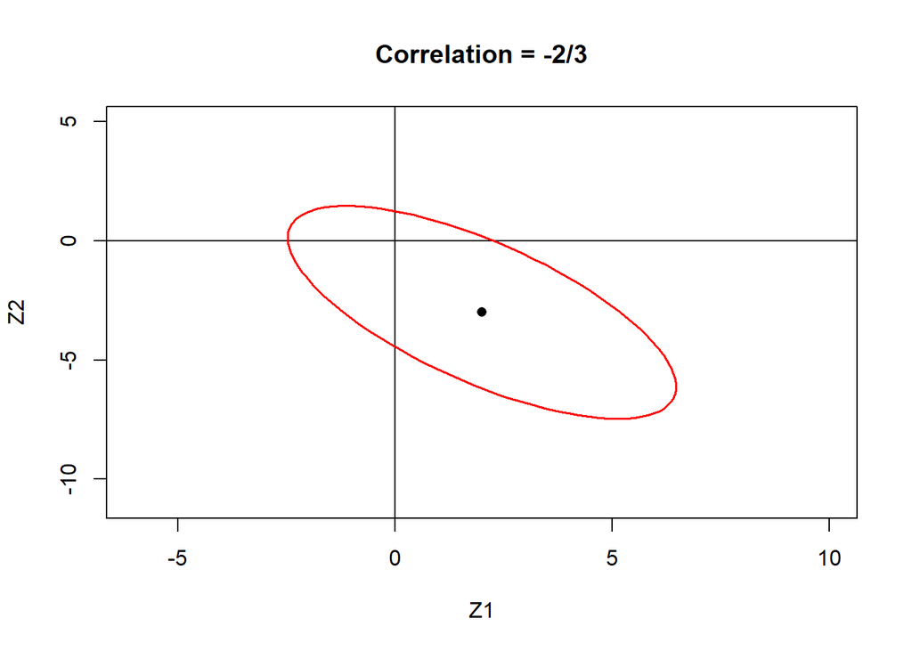

```r
plot(muz[1], muz[2], xlab="Z1", ylab="Z2", main="Correlation = -2/3", pch=16,
     xlim=c(-6,10), ylim=c(-11,5))
library(ellipse)
abline(0,0)
abline(v=0)
lines(ellipse(x=Sigz,centre=muz,level=0.95),col="red",lwd=1.5)
```

### 2.5

If we change the sign of $\rho$ and set it to $2/3$ the vector $\mu$ does not change but the covariance matrix becomes

```r
Sigz2
```

```
##           [,1]      [,2]
## [1,] 0.6666667 0.3333333
## [2,] 0.3333333 0.6666667
```

Since $Z_1$ and $Z_2$ are now positive correlated, we expect the ellipses to have the opposite orientation of the other one. In addition to this both the variances and the covariances are smaller in absolute value, so we expect the second ellipse to be smaller than the first one.

The ratio between the eigenvalues changes so the ratio between the squared semiaxes should change too.

```r
eigen(Sigz)$values
```

```
## [1] 5.666667 1.000000
```

```r
eigen(Sigz2)$values
```

```
## [1] 1.0000000 0.3333333
```

# Esercizio 3

We upload the dataset and perform PCA on the standardized variables, we also report the standard deviations.

```r
pendigits.Npca <- prcomp(pendigits, center=T, scale=T)
summary(pendigits.Npca)
```

```
## Importance of components:
##                           PC1    PC2    PC3     PC4     PC5     PC6     PC7
## Standard deviation     2.1718 1.7970 1.6052 1.10894 1.03107 0.89294 0.77888
## Proportion of Variance 0.2948 0.2018 0.1610 0.07686 0.06644 0.04983 0.03792
## Cumulative Proportion  0.2948 0.4966 0.6577 0.73452 0.80096 0.85079 0.88871
##                            PC8     PC9    PC10    PC11    PC12    PC13    PC14
## Standard deviation     0.74044 0.64096 0.54611 0.45882 0.33511 0.28369 0.24084
## Proportion of Variance 0.03427 0.02568 0.01864 0.01316 0.00702 0.00503 0.00363
## Cumulative Proportion  0.92297 0.94865 0.96729 0.98045 0.98747 0.99250 0.99612
##                           PC15    PC16
## Standard deviation     0.18511 0.16673
## Proportion of Variance 0.00214 0.00174
## Cumulative Proportion  0.99826 1.00000
```

### 3.1

To choose how many components to retain in order to achieve a satisfactory low-dimensional representation of the data we consider we consider a few indicators:

1. the number of variables that allows to explain at lease $80/85 \%$ of the total variability;
2. the numer of variables with corresponding variance greater than 1;
3. an elbow on the screeplot.

We observe from the previous result that with 5 PC we explain the $80\%$ of the total variability and with 6 the $85\%$.

```r
pendigits.Npca$sdev^2
```

```
##  [1] 4.71658637 3.22911210 2.57680630 1.22974181 1.06309928 0.79733935
##  [7] 0.60665163 0.54825156 0.41082409 0.29823086 0.21051266 0.11229691
## [13] 0.08048105 0.05800212 0.03426450 0.02779941
```

The first 5 variables have variances grater than 1, we use the screeplot to confirm 5 as the number of vaiables to be chosen.

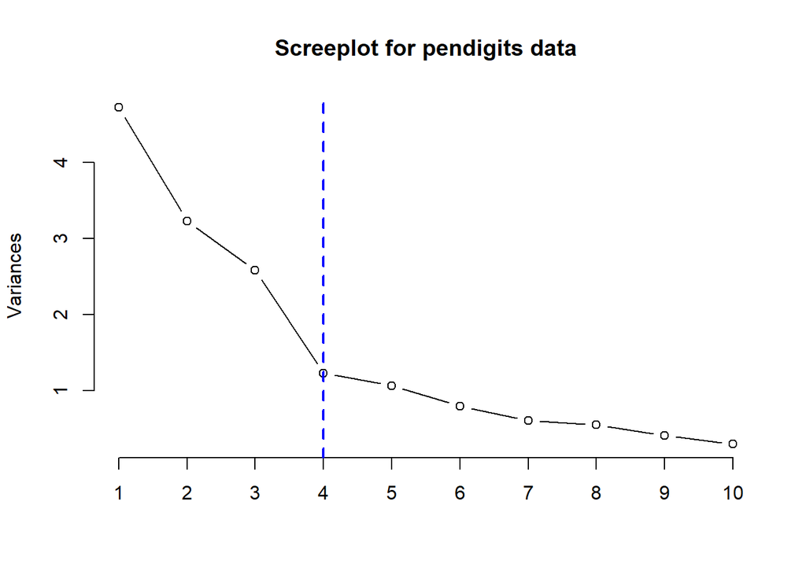

```r
screeplot(pendigits.Npca, type="lines", main="Screeplot for pendigits data")
abline(v=4, col="blue", lty=2, lwd=2)
```

The screeplot actually shows an evident elbow corresponding to the fourth variable. Since two indicators out of three suggest using 5 variables and by using four we explain less than $75\%$ of the total variability, we choose to use 5 variables for the lower-dimensional representation of the dataset.

### 3.2

We consider only the first three principal components and investigate their multivariate normality by looking at the distribution of the Mahalanobis distances.

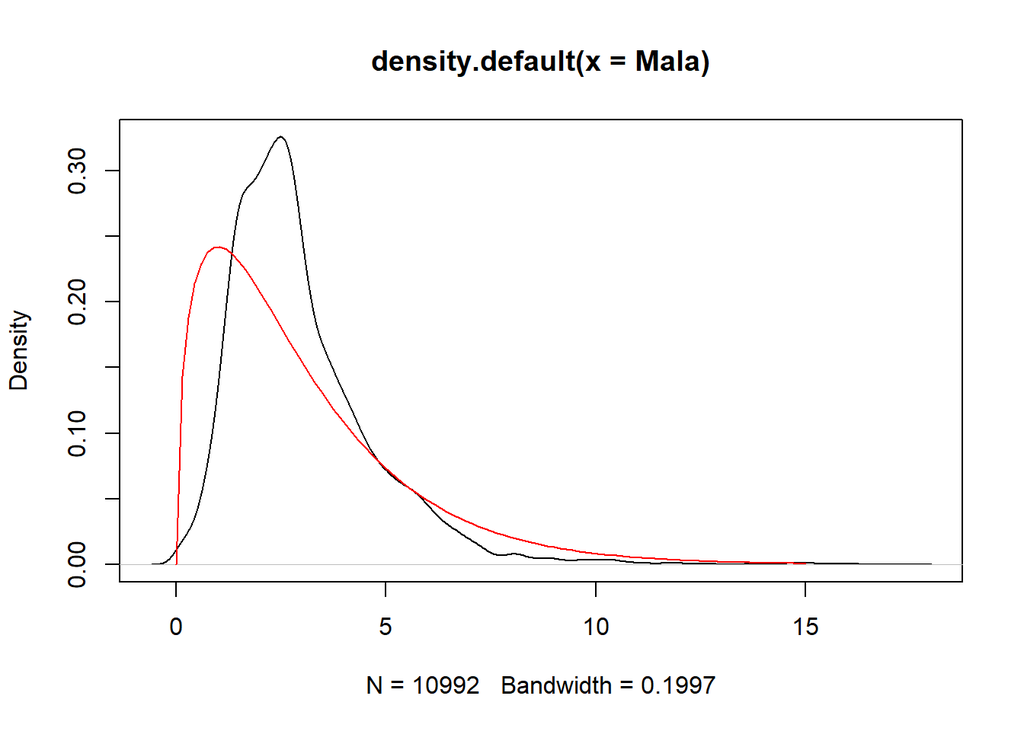

```r
d <- as.data.frame(pendigits.Npca$x[,1:3])
Mala <- mahalanobis(d,center=colMeans(d),cov=round(var(d),4))
plot(density(Mala))
curve(dchisq(x, df = 3), from = 0, to = 15, add=TRUE,col = "red")
```

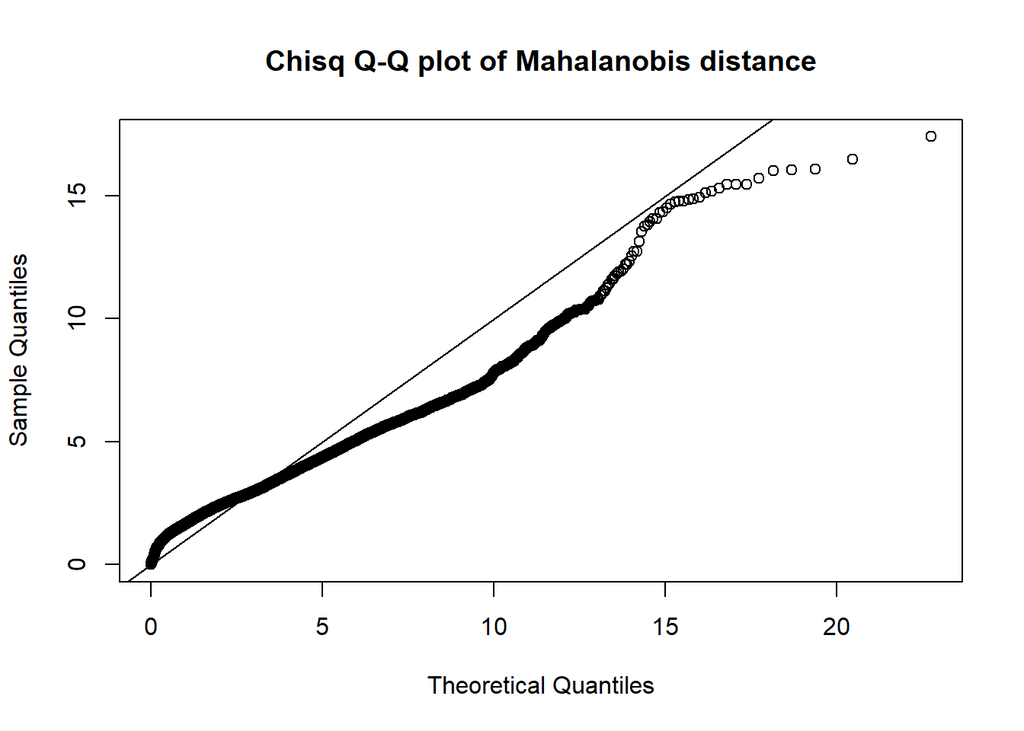

```r
plot(qchisq(ppoints(Mala), df=3), sort(Mala), main= "Chisq Q-Q plot of Mahalanobis distance",
     xlab="Theoretical Quantiles",ylab="Sample Quantiles")
abline(0,1)
```

The qqplot does not support the normality of data because it stays below the line $y=x$ and because of its tails. We can get to the same statement by looking at the distribution of the Mahalanobis distances and the true distribution of a Chi square with three degrees of freedom. The same consideration can be retrieved from the scatterplot of the principal components and from the plots of their univariate densities.

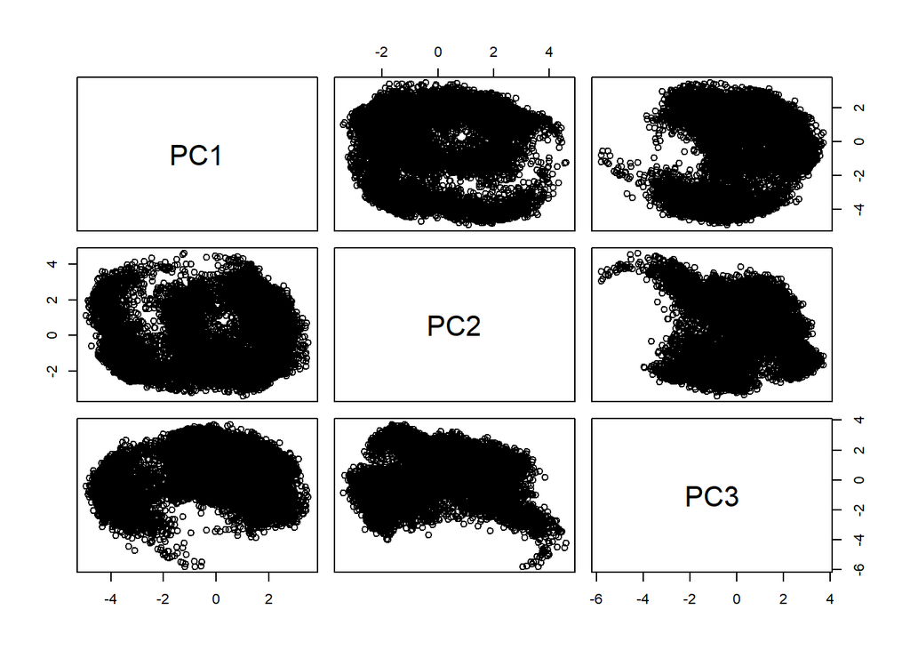

```r
pairs(d)
```

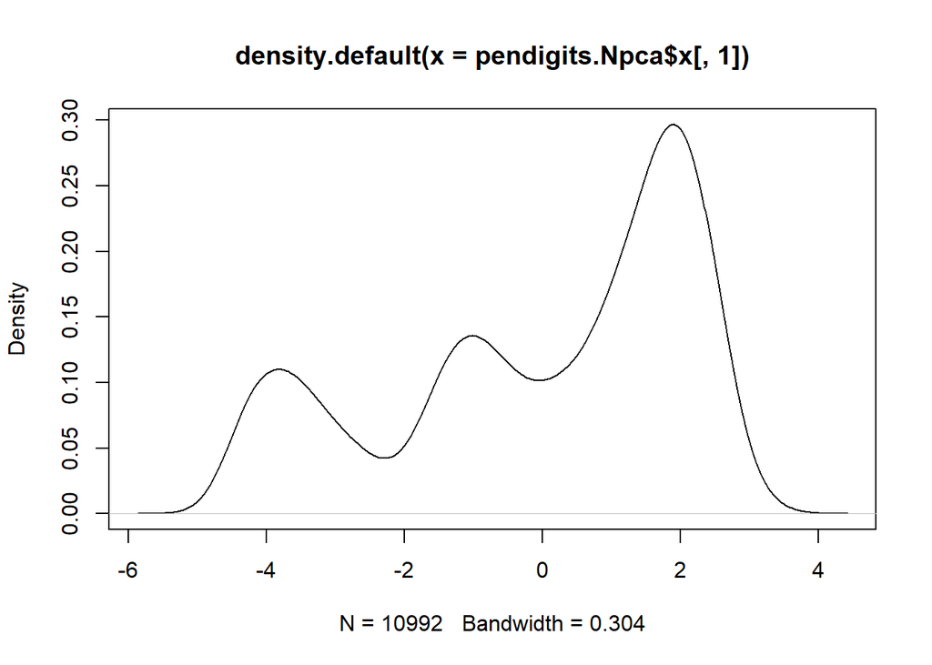

```r
plot(density(pendigits.Npca$x[,1]))
```

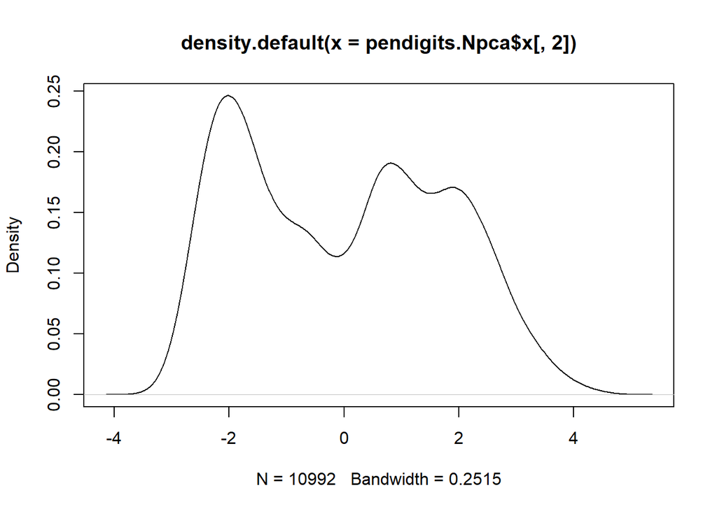

```r
plot(density(pendigits.Npca$x[,2]))
```

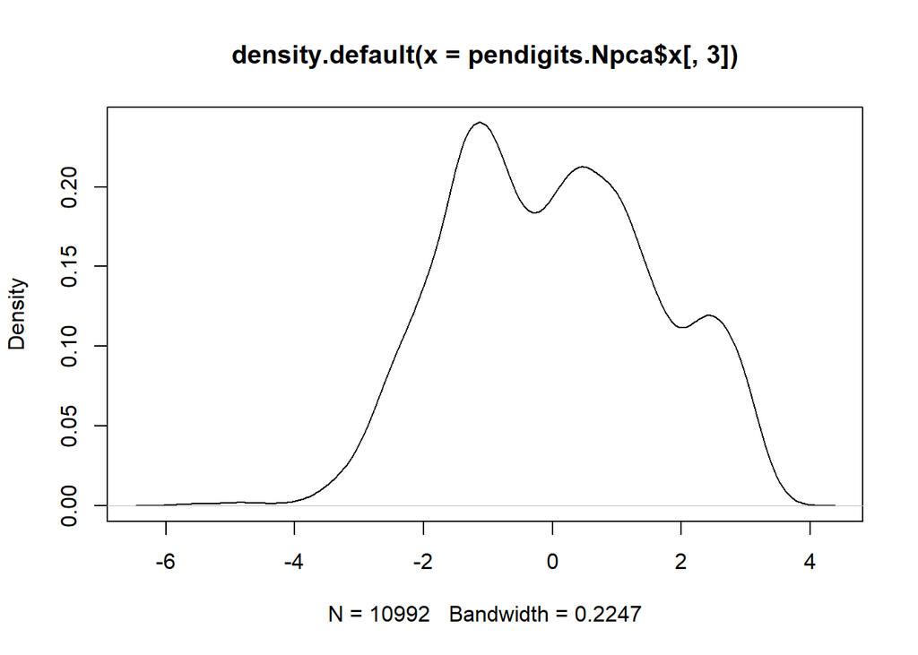

```r
plot(density(pendigits.Npca$x[,3]))
```

The densities show different maximums and look like mixtures of normal distributions. Since the dataset containts diffenent digits it could be interesting to repeat this analysis considering one digits at a time or groups of digits, isolating them and investigating their distribution with respect of the first three components. This could support or reject our consideration about the mixture of normal distributions.

### 3.3

We repeat the scatterplot and we color the points according to the digit they represent.

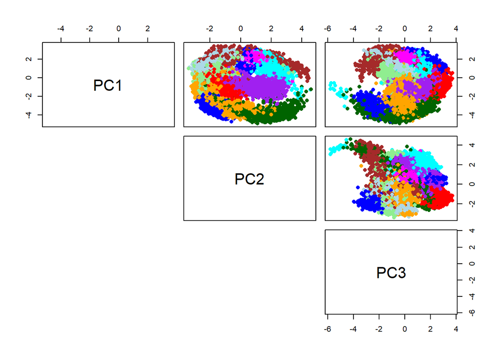

```r
pairs(d,lower.panel=NULL,col=digit.col,pch=16)
```

The dataclouds show some underlying structure because they are visibly divided in clusters associated to different colors (and digits). This means that the first three principal components capture the sructure of the dataset which colud be impossible to visualize with sixteen features.

### 3.4

We look for outliers in the first three components by looking at their boxplots.

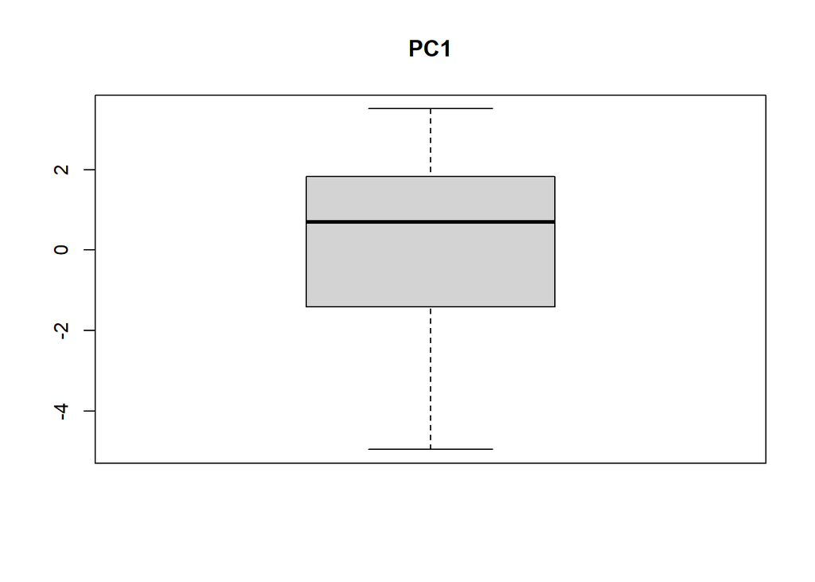

```r
boxplot(pendigits.Npca$x[,1],main="PC1")
```

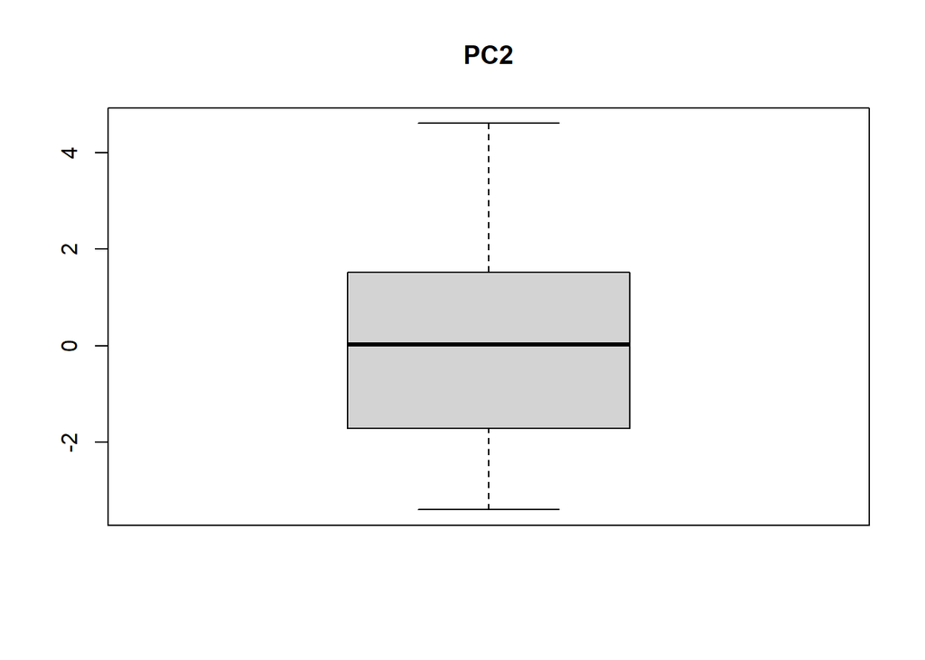

```r
boxplot(pendigits.Npca$x[,2],main="PC2")
```

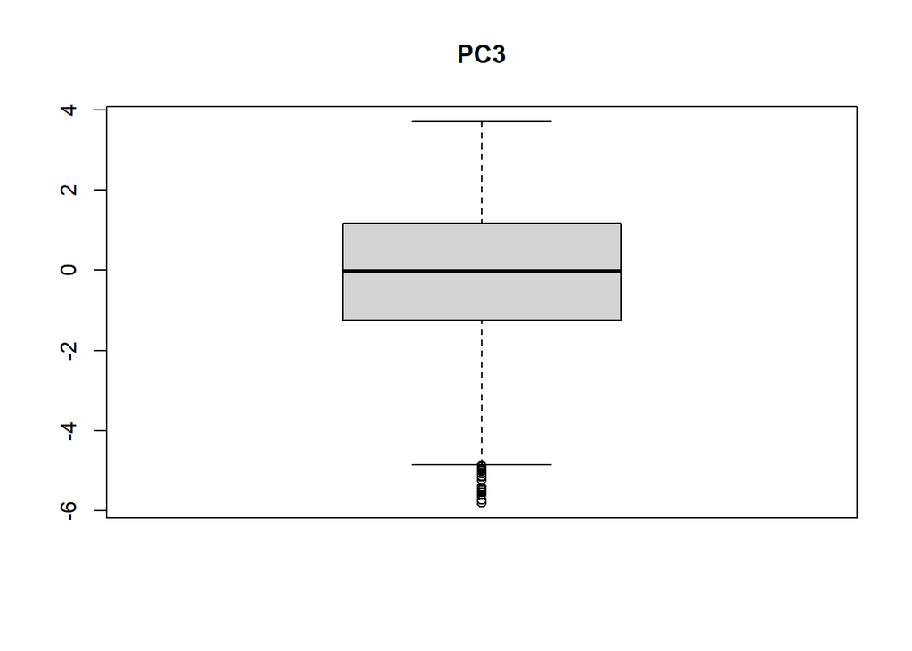

```r
boxplot(pendigits.Npca$x[,3],main="PC3")
```

The first two PC do not show evident outliers while the third one does. They correspond to low values of PC3 and they are evident in the scatterplot too, in fact the two panels plotting PC3 show a tail-looking part of the data distribution that corresponds to low values of PC3.

We now investigate the outliers.

```r
outs <- which(pendigits.Npca$x[,3]< -4.5) # value chosen on the base of the boxplot
outs_dig <- pendig$digit[outs]

table(outs_dig)
```

```
## outs_dig
##  0  9
##  2 24
```

The outliers are just 26 instances, 2 representing the digit $0$ and 24 representingthe digit $9$.

```r
table(pendig$digit)
```

```
##
##    0    1    2    3    4    5    6    7    8    9
## 1143 1143 1144 1055 1144 1055 1056 1142 1055 1055
```

The majority of the outliers correspond to digit $9$ but they only correspond to a small fraction of the $9$’s present in the dataset. This could be due to the fact that some people included in the dataset creation wrote the digit $9$ in a strane way, diffenent from the other people, for example starting from the bottom and ending with the small circle instead of doing the opposite.